# Chapter 4 Simultaneous Inferences and Other Topics

Bryan Goodrich

2015-08-08

# Chapter 4 – Simultaneous Inferences and Other Topics in Regression Analysis

## Load the data sets

```r
data("CH01TA01", package = "ALSM")
data("CH04TA02", package = "ALSM")
```

## Input the Toluca Company Data

```r
.data  <- CH01TA01
names(.data) <- c('x', 'y')
fit  <- lm(y ~ x, .data)
```

## Bonferroni Joint Confidence Intervals (p 156)

As the authors explain, we’re looking for `B = t(1 - 0.10/4; 23)` for the 90% joint confidence interval. But notice that the `confint` funtion uses a 95% confidence interval `t(1 - 0.05/2; 23)` that equals `B`. Therefore, all we require in this instance is to use `confint(fit)` to get the correct result.

The reason this works is because the Bonferroni correction is just a modification to the t-statistic. The `confint` function uses the level parameter to produce the `alpha = 0.05` in the above case. Therefore, what we require is a level to turn `1 - 0.05/2` into `1 - 0.1/4`, or a level such that:

> `1 - a/2 = 1 - (1 - level)/2 = 1 - alpha/4, alpha = 0.1, a = (1 - level)`

The 4, as we shall see in multiple regression, is really just `2g`, where `g` is the number of confidence coefficients in the family, in this case 2. It turns out that a `level = 1 - alpha/g = 1 - 0.1/2` will give us the desired result:

> `1 - a/2 = 1 - (1 - level)/2 = 1 - (1 - (1 - alpha/g))/2 = 1 - alpha/2g`

In this case, `1 - alpha/g = 0.95`, just is the default level of confint.

```r
confint(fit, level = (1 - 0.1/2))
```

```
##                2.5 %     97.5 %
## (Intercept) 8.213711 116.518006
## x           2.852435   4.287969
```

## Simultaneous Estimation of Mean Responses (p 158)

#### The Working-Hotelling Procedure (90% confidence coefficient)

```r
ci.wh <- function(model, newdata, alpha = 0.1)
{
  df    <- nrow(model.frame(model)) - length(coef(model))  # 23
  W     <- sqrt( 2 * qf(1 - alpha, 2, df) )                # 2.2580
  ci    <- predict(model, newdata, se.fit = TRUE)
  x <- cbind(
    'x'   = newdata,
    's'   = ci$se.fit,
    'fit' = ci$fit,
    'lwr' = ci$fit - W * ci$se.fit,
    'upr' = ci$fit + W * ci$se.fit)

  return(x)
}

new <- data.frame(x = c(30, 65, 100))
ci.wh(fit, new)
```

```
##     x         s      fit      lwr      upr
## 1  30 16.969741 169.4719 131.1542 207.7897
## 2  65  9.917579 294.4290 272.0351 316.8229
## 3 100 14.272328 419.3861 387.1591 451.6130
```

## Simultaneous Estimation of Mean Responses (p 159)

#### The Bonferroni Procedure (90% confidence coefficient)

As in the above Bonferroni correction, we require `level = (1 - alpha/g)`. For clarity, part of the return object includes `se.fit` (set to true), which are the standard errors and `residual.scale`, which is equal to the positive squart root of the MSE. This will be used in calculations below.

```r
predict(fit, new, int = "c", level = (1 - 0.1/nrow(new)), se.fit = TRUE)
```

```
## $fit
##        fit      lwr      upr
## 1 169.4719 131.0570 207.8868
## 2 294.4290 271.9783 316.8797
## 3 419.3861 387.0774 451.6947
##
## $se.fit
##         1         2         3
## 16.969741  9.917579 14.272328
##
## $df
## [1] 23
##
## $residual.scale
## [1] 48.82331
```

## Simultaneous Prediction Intervals for New Observations (p 160)

#### The Scheffe and Bonferroni Procedures (95% confidence coefficient)

```r
ci.sim <- function(model, newdata, type = c("B", "S"), alpha = 0.05)
{
  g  <- nrow(newdata)
  CI <- predict(model, newdata, se.fit = TRUE)
  M  <- ifelse(match.arg(type) == "B",
          qt(1 - alpha / (2*g), model$df),              # B = (4.9a)
          sqrt( g * qf( 1 - alpha, g, model$df)))       # S = (4.8a)

  spred <- sqrt( CI$residual.scale^2 + (CI$se.fit)^2 )  # (2.38)
  x <- data.frame(
    "x"     = newdata,
    "spred" = spred,
    "fit"   = CI$fit,
    "lower" = CI$fit - M * spred,
    "upper" = CI$fit + M * spred)

  return(x)
}

new <- data.frame(x = c(80, 100))
ci.sim(fit, new, type = "S")
```

```
##     x    spred      fit    lower    upper
## 1  80 49.91095 347.9820 217.4073 478.5568
## 2 100 50.86664 419.3861 286.3111 552.4610
```

```r
ci.sim(fit, new, type = "B")
```

```
##     x    spred      fit    lower    upper
## 1  80 49.91095 347.9820 228.3018 467.6622
## 2 100 50.86664 419.3861 297.4142 541.3579
```

## Input the Warehouse data

```r
.data <- CH04TA02
names(.data) <- c('x', 'y')
```

## TABLE 4.2 and FIGURE 4.1 (pp 162-4)

Included in the summary and anova output are the values calculated on pages 163 and 164.

```r
fit <- lm(y ~ 0 + x, .data)   # alternate way to exclude intercept: lm(y ~ x - 1)
tab <- transform(.data,
  x   = round(x, 0),
  y   = round(y, 0),
  xy  = round(x * y, 0),
  xsq = round(x * x, 0),
  fit = round(fitted(fit), 2),
  e   = round(resid(fit), 2))

rbind(tab, Total = colSums(tab))
```

```
##          x    y     xy    xsq     fit      e
## 1       20  114   2280    400   93.71  20.29
## 2      196  921 180516  38416  918.31   2.69
## 3      115  560  64400  13225  538.81  21.19
## 4       50  245  12250   2500  234.26  10.74
## 5      122  575  70150  14884  571.60   3.40
## 6      100  475  47500  10000  468.53   6.47
## 7       33  138   4554   1089  154.61 -16.61
## 8      154  727 111958  23716  721.53   5.47
## 9       80  375  30000   6400  374.82   0.18
## 10     147  670  98490  21609  688.74 -18.74
## 11     182  828 150696  33124  852.72 -24.72
## 12     160  762 121920  25600  749.64  12.36
## Total 1359 6390 894714 190963 6367.28  22.72
```

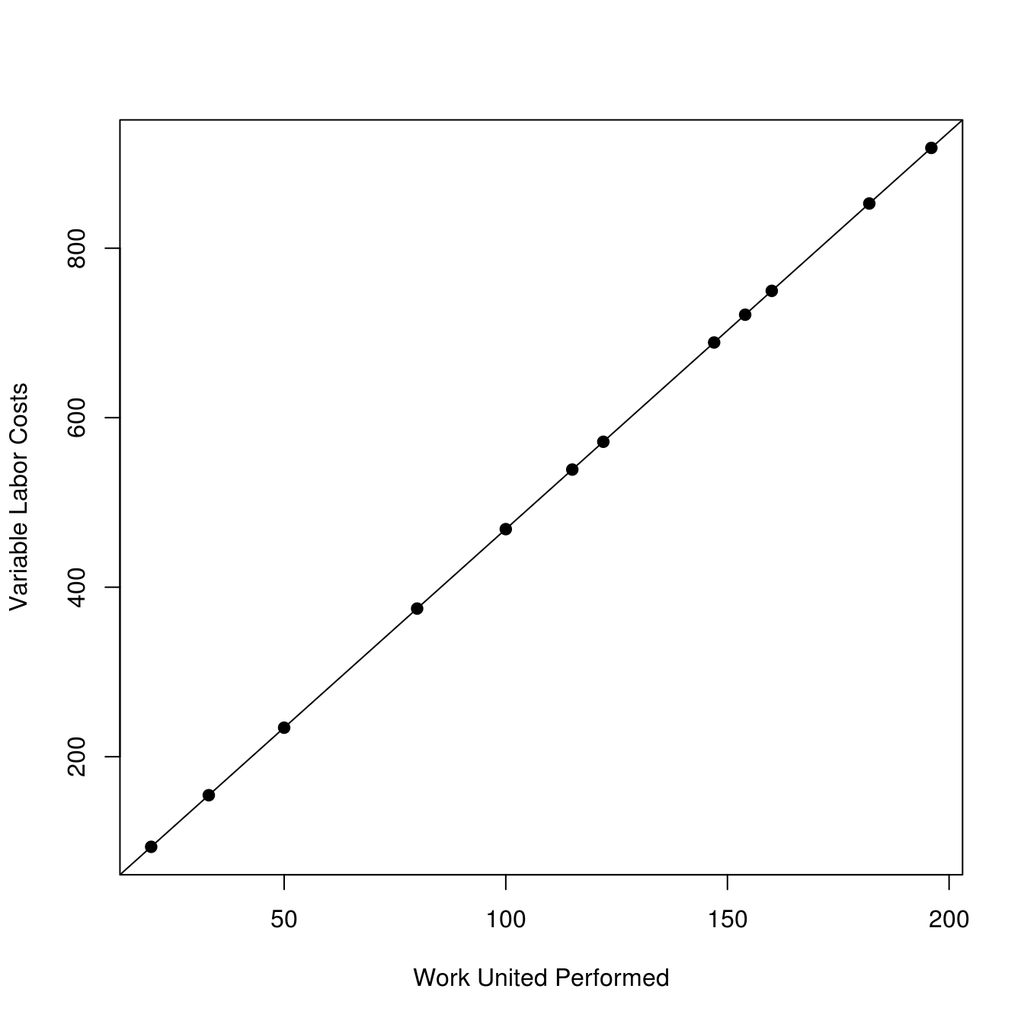

```r
plot(.data$x, fitted(fit), pch = 19, xlab = "Work United Performed", ylab = "Variable Labor Costs")
abline(fit)
```

```r
# Some of the results from pp 163-4 are included or derivable from these
summary(fit)
```

```
##
## Call:
## lm(formula = y ~ 0 + x, data = .data)
##
## Residuals:
##     Min      1Q  Median      3Q     Max
## -24.720  -4.020   4.432  11.141  21.194
##
## Coefficients:
##   Estimate Std. Error t value Pr(>|t|)
## x  4.68527    0.03421     137   <2e-16 ***
## ---
## Signif. codes:  0 '***' 0.001 '**' 0.01 '*' 0.05 '.' 0.1 ' ' 1
##
## Residual standard error: 14.95 on 11 degrees of freedom
## Multiple R-squared:  0.9994, Adjusted R-squared:  0.9994
## F-statistic: 1.876e+04 on 1 and 11 DF,  p-value: < 2.2e-16
```

```r
anova(fit)
```

```
## Analysis of Variance Table
##
## Response: y
##           Df  Sum Sq Mean Sq F value    Pr(>F)
## x          1 4191980 4191980   18762 < 2.2e-16 ***
## Residuals 11    2458     223
## ---
## Signif. codes:  0 '***' 0.001 '**' 0.01 '*' 0.05 '.' 0.1 ' ' 1
```

```r
confint(fit)
```

```
##      2.5 %   97.5 %
## x 4.609989 4.760559
```